# Statistical analysis

[figure not shown]

```
##
## Call:
## lm(formula = nflex_5 ~ nflex_3 + nflex_2 + nflex_7, data = nflex_inv_reduct_msa)
##
## Residuals:
##     Min      1Q  Median      3Q     Max
## -3.8334 -0.8137  0.0255  0.9096  3.1683
##
## Coefficients:
##             Estimate Std. Error t value        Pr(>|t|)
## (Intercept)  3.14327    0.45557   6.900 0.0000000000249 ***
## nflex_3      0.15303    0.05321   2.876        0.004279 **
## nflex_2     -0.11123    0.07185  -1.548        0.122527
## nflex_7      0.20282    0.05714   3.550        0.000439 ***
## ---
## Signif. codes:  0 '***' 0.001 '**' 0.01 '*' 0.05 '.' 0.1 ' ' 1
##
## Residual standard error: 1.239 on 346 degrees of freedom
## Multiple R-squared:  0.1005, Adjusted R-squared:  0.09266
## F-statistic: 12.88 on 3 and 346 DF,  p-value: 0.00000005363
##
##
## ASSESSMENT OF THE LINEAR MODEL ASSUMPTIONS
## USING THE GLOBAL TEST ON 4 DEGREES-OF-FREEDOM:
## Level of Significance =  0.05
##
## Call:
##  gvlma(x = monModel)
##
##                     Value p-value                Decision
## Global Stat        3.4090  0.4918 Assumptions acceptable.
## Skewness           1.0458  0.3065 Assumptions acceptable.
## Kurtosis           1.1689  0.2796 Assumptions acceptable.
## Link Function      0.9778  0.3227 Assumptions acceptable.
## Heteroscedasticity 0.2166  0.6417 Assumptions acceptable.
##
## Global test deletion statistics.
##
## Linear Model:
##  lm(formula = nflex_5 ~ nflex_3 + nflex_2 + nflex_7, data = nflex_inv_reduct_msa)
```

[output cut: 73 more lines]

```
## 324                    33.62935                  0.2530056
## 342                    46.95587                  0.2306356
##
##
## Unusual observations for Directional Stat4:
##     Delta Directional Stat4 (%)  Directional Stat4 p-value
## 2                      68.39937                  0.5459029
## 10                    139.93867                  0.4709938
## 13                    152.74099                  0.4593944
## 24                     74.30913                  0.5389403
## 26                     96.51329                  0.5141581
## 230                   -61.35785                  0.7723595
## 266                   -74.05632                  0.8126271
## 280                   -65.76347                  0.7853914
## 340                   -57.26060                  0.7609448
```

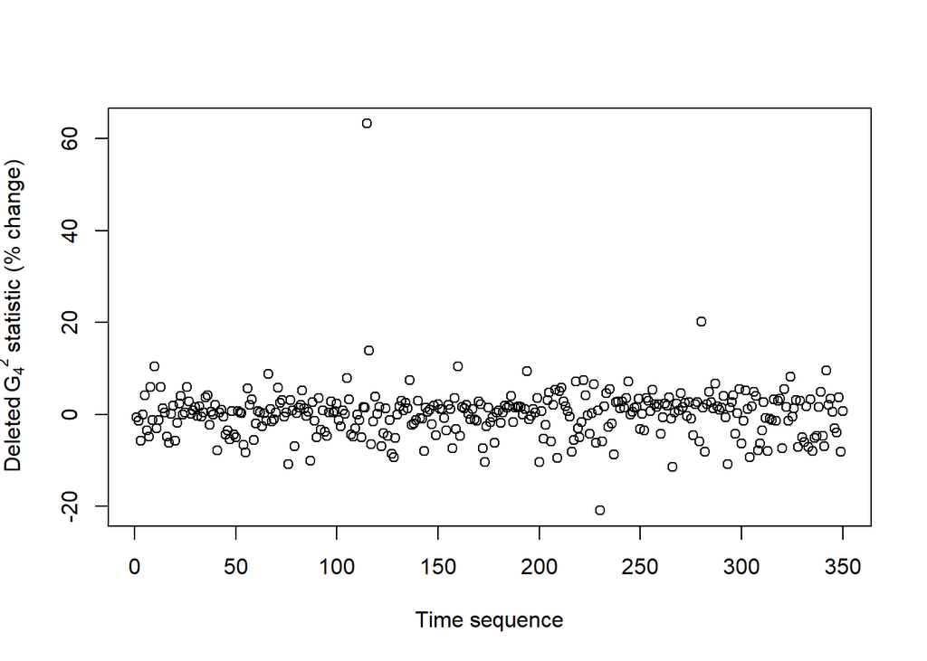

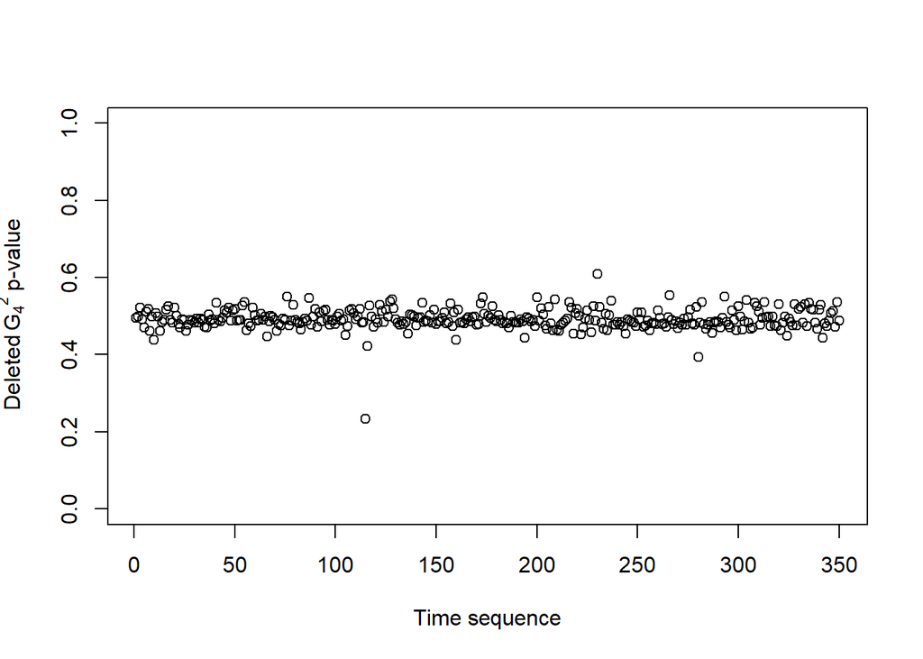

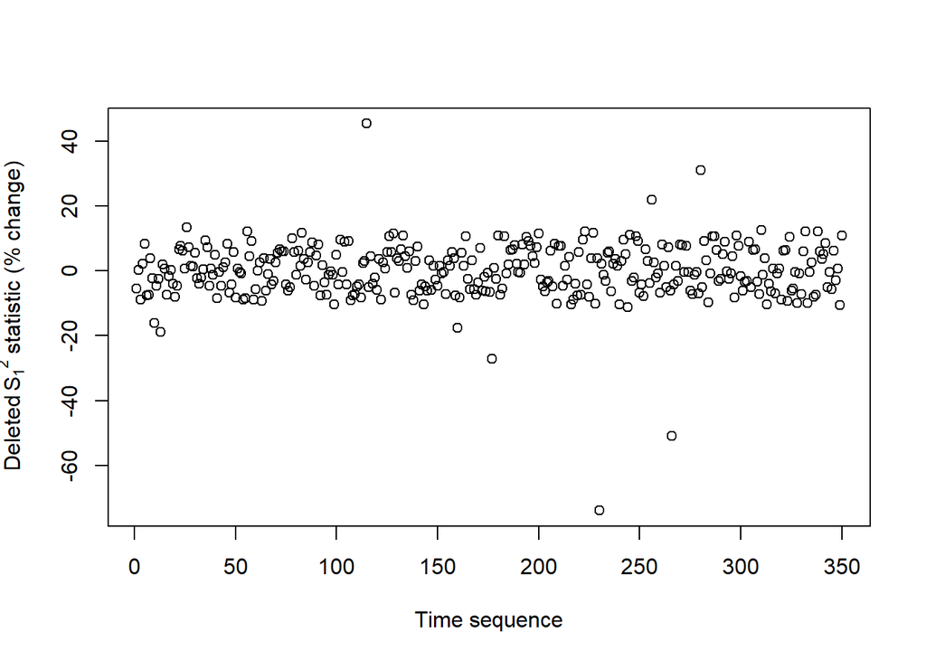

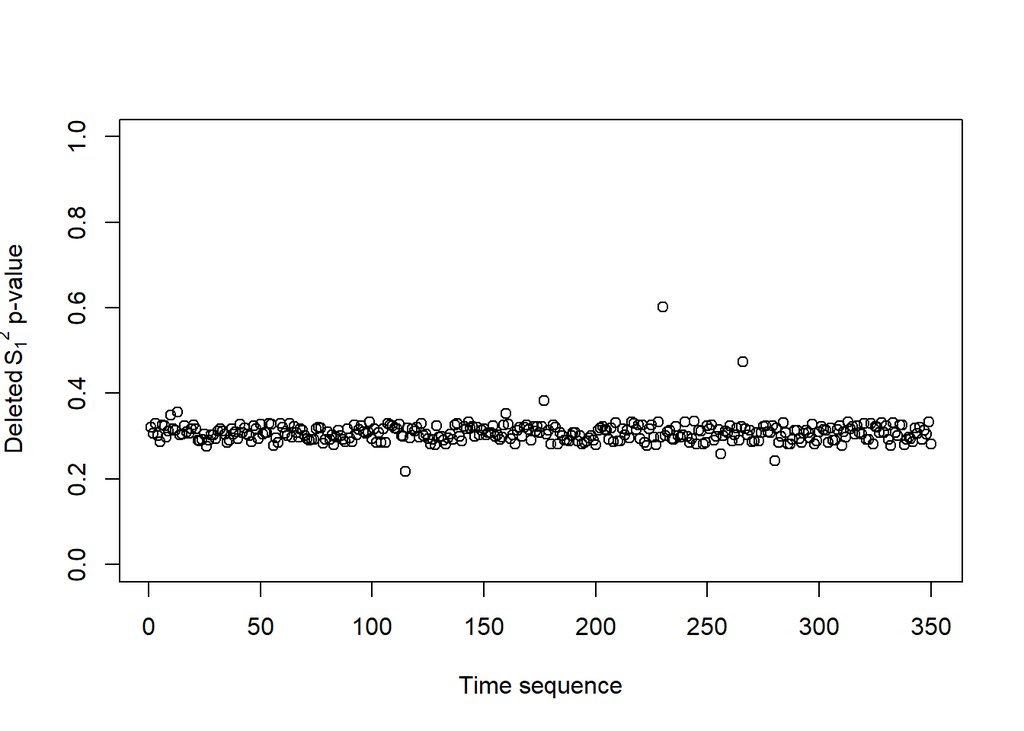

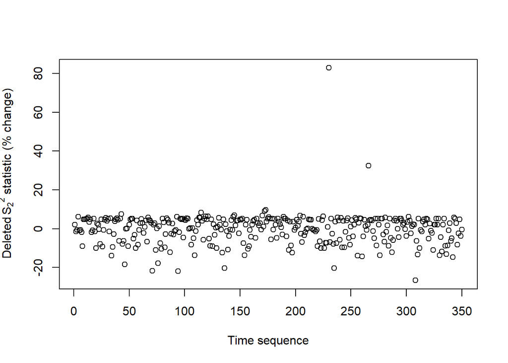

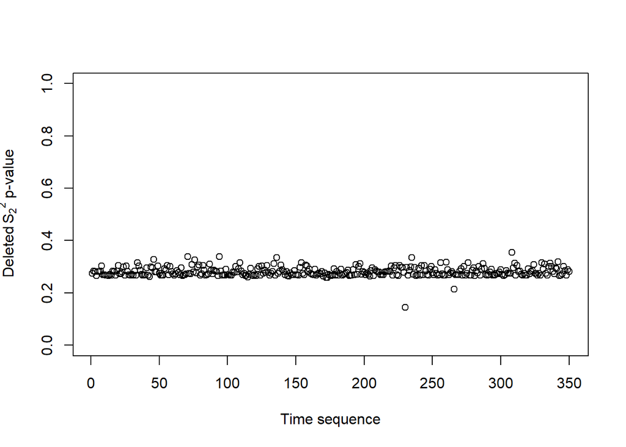

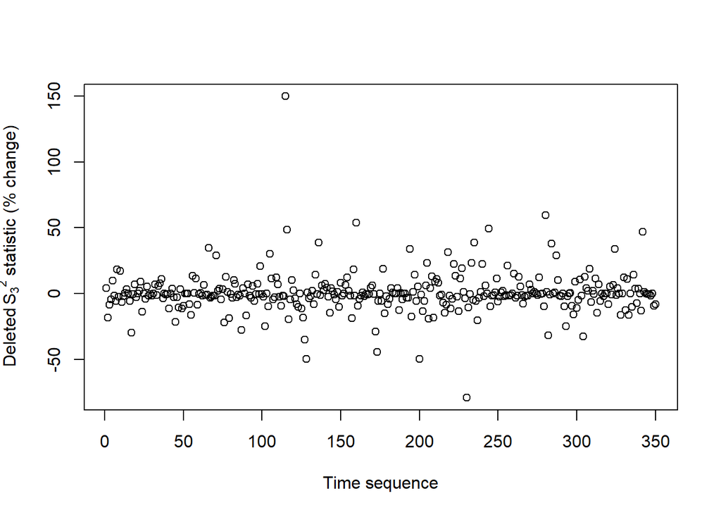

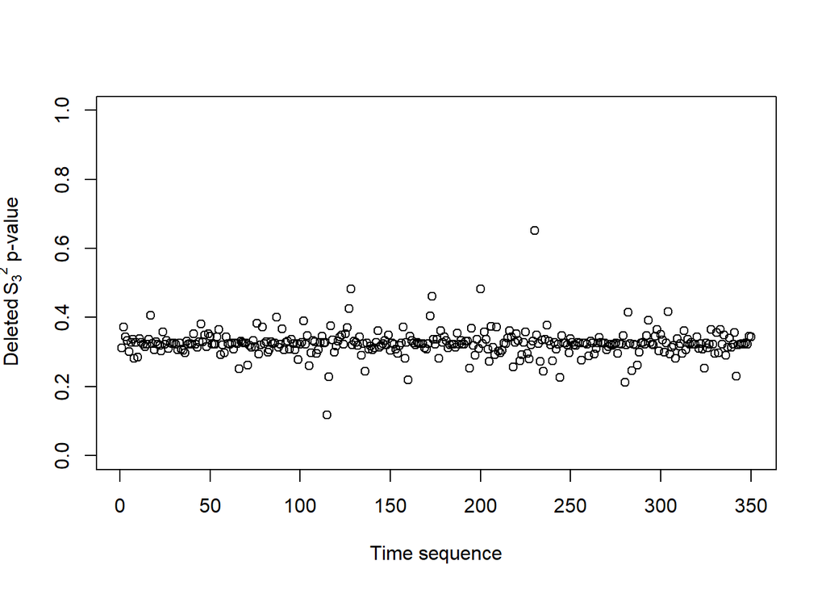

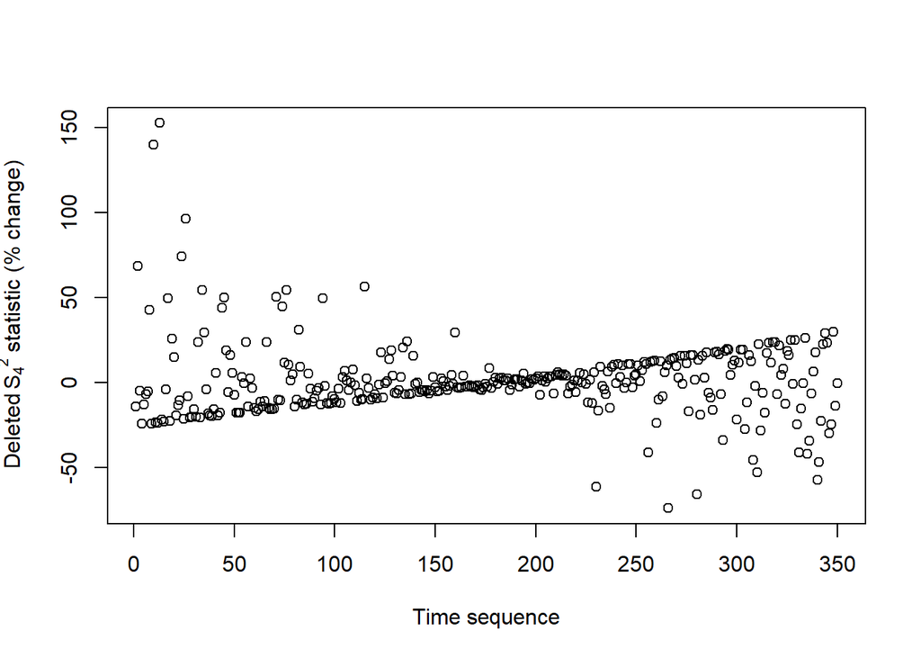

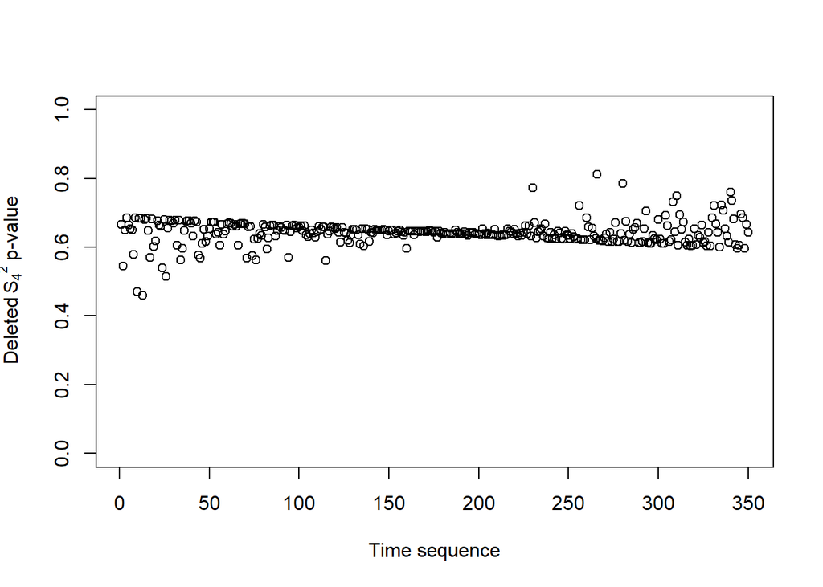

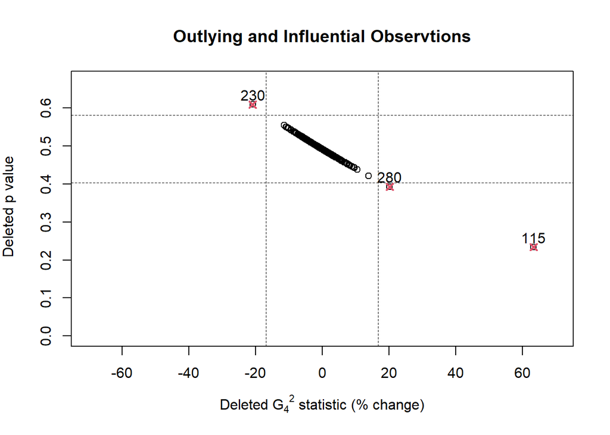

[13 more figures not shown]

```r
lm3 = lm(nflex_5~nflex_3+nflex_2+nflex_7, data=nflex_inv_reduct_msa)
ConditionRegression(lm3)
```

[figure not shown]

```
##
## Call:
## lm(formula = nflex_7 ~ nflex_3 + nflex_5 + nflex_2, data = nflex_inv_reduct_msa)
##
## Residuals:
##     Min      1Q  Median      3Q     Max
## -3.0011 -0.8526  0.0217  0.6712  3.2177
##
## Coefficients:
##             Estimate Std. Error t value          Pr(>|t|)
## (Intercept)  3.09053    0.41723   7.407 0.000000000000994 ***
## nflex_3      0.19999    0.04859   4.116 0.000048303130665 ***
## nflex_5      0.17325    0.04881   3.550          0.000439 ***
## nflex_2     -0.24560    0.06532  -3.760          0.000199 ***
## ---
## Signif. codes:  0 '***' 0.001 '**' 0.01 '*' 0.05 '.' 0.1 ' ' 1
##
## Residual standard error: 1.145 on 346 degrees of freedom
## Multiple R-squared:  0.1609, Adjusted R-squared:  0.1536
## F-statistic: 22.11 on 3 and 346 DF,  p-value: 0.0000000000004003
##
##
## ASSESSMENT OF THE LINEAR MODEL ASSUMPTIONS
## USING THE GLOBAL TEST ON 4 DEGREES-OF-FREEDOM:
## Level of Significance =  0.05
##
## Call:
##  gvlma(x = monModel)
##
##                      Value p-value                Decision
## Global Stat        5.28734 0.25906 Assumptions acceptable.
## Skewness           1.40463 0.23595 Assumptions acceptable.
## Kurtosis           0.77417 0.37893 Assumptions acceptable.
## Link Function      0.04667 0.82896 Assumptions acceptable.
## Heteroscedasticity 3.06187 0.08015 Assumptions acceptable.
##
## Global test deletion statistics.
##
## Linear Model:
##  lm(formula = nflex_7 ~ nflex_3 + nflex_5 + nflex_2, data = nflex_inv_reduct_msa)
```

[output cut: 70 more lines]

```
## 298                   139.99145                  0.7378669
## 300                   184.85813                  0.7153920
## 308                   221.01781                  0.6987003
## 341                   -99.95253                  0.9962444
##
##
## Unusual observations for Directional Stat4:
##     Delta Directional Stat4 (%)  Directional Stat4 p-value
## 9                     -36.17934                 0.16214504
## 64                    -16.44525                 0.10971383
## 76                    -20.22651                 0.11808327
## 78                    -22.82691                 0.12424780
## 256                    18.77980                 0.05651260
## 332                    47.23364                 0.03373461
## 340                    18.89523                 0.05639276
```

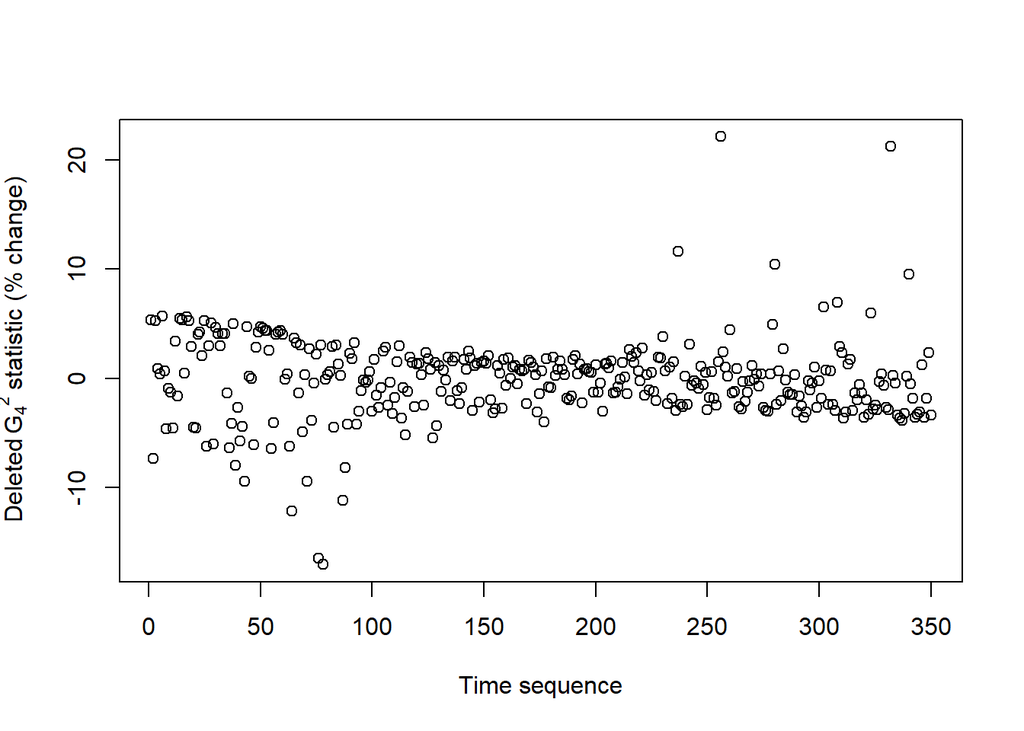

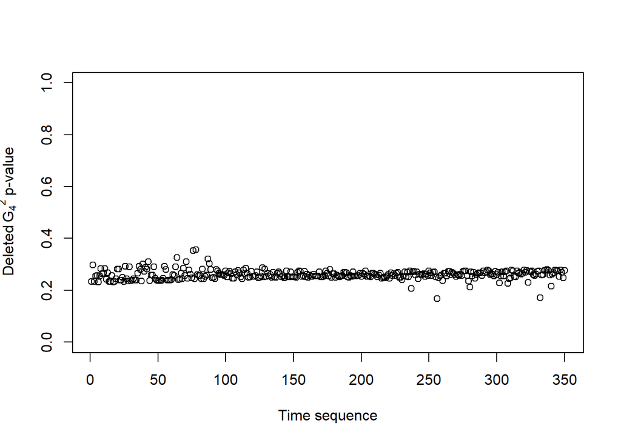

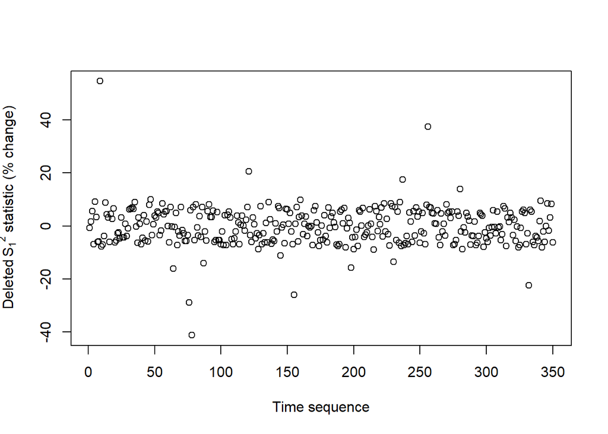

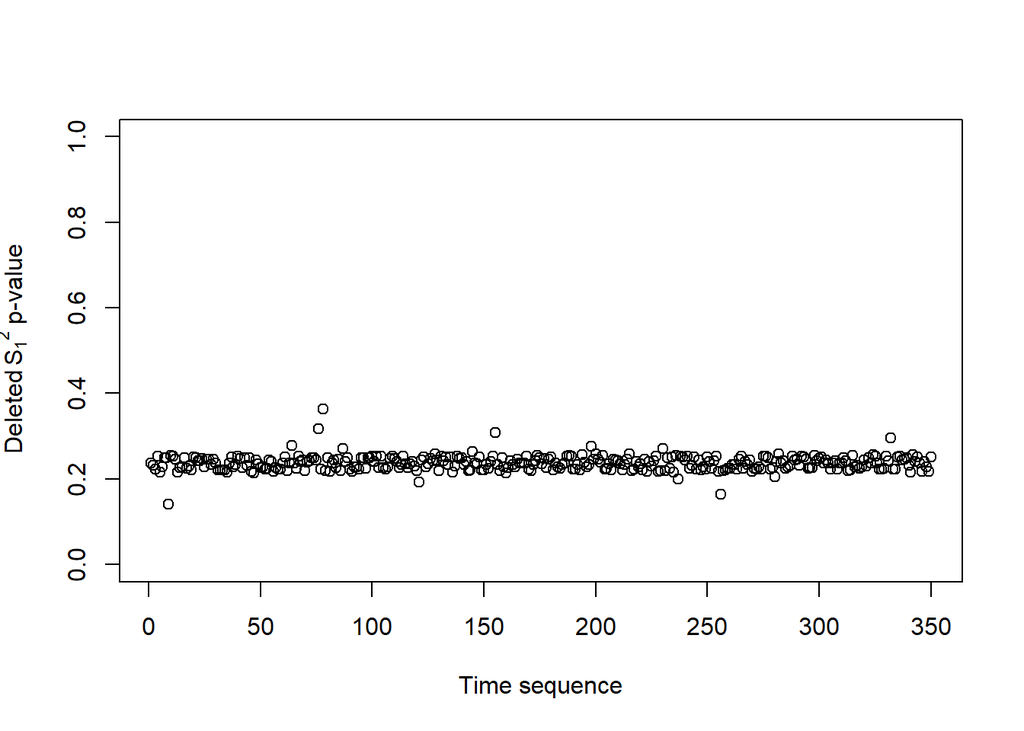

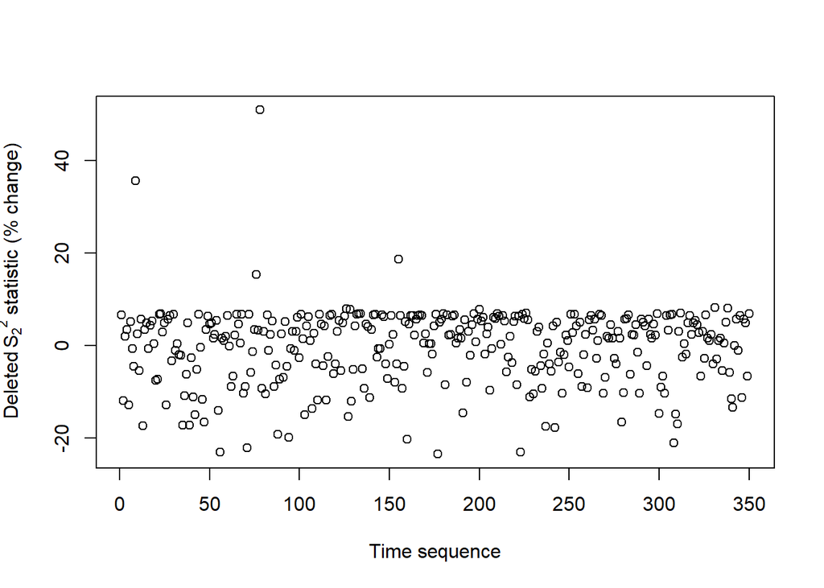

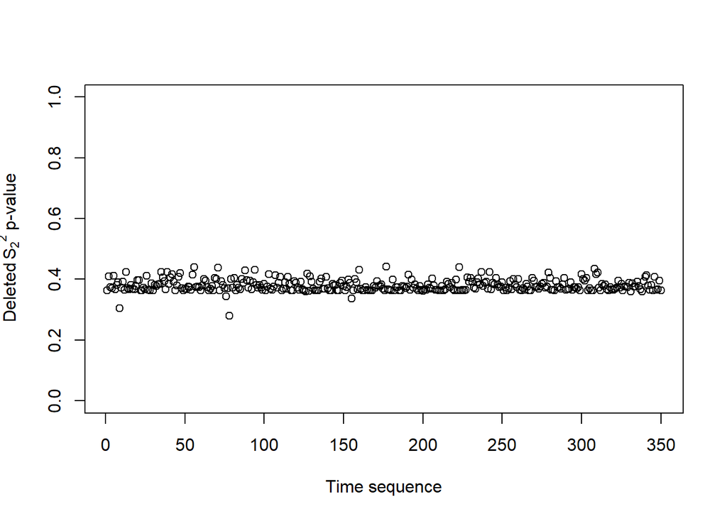

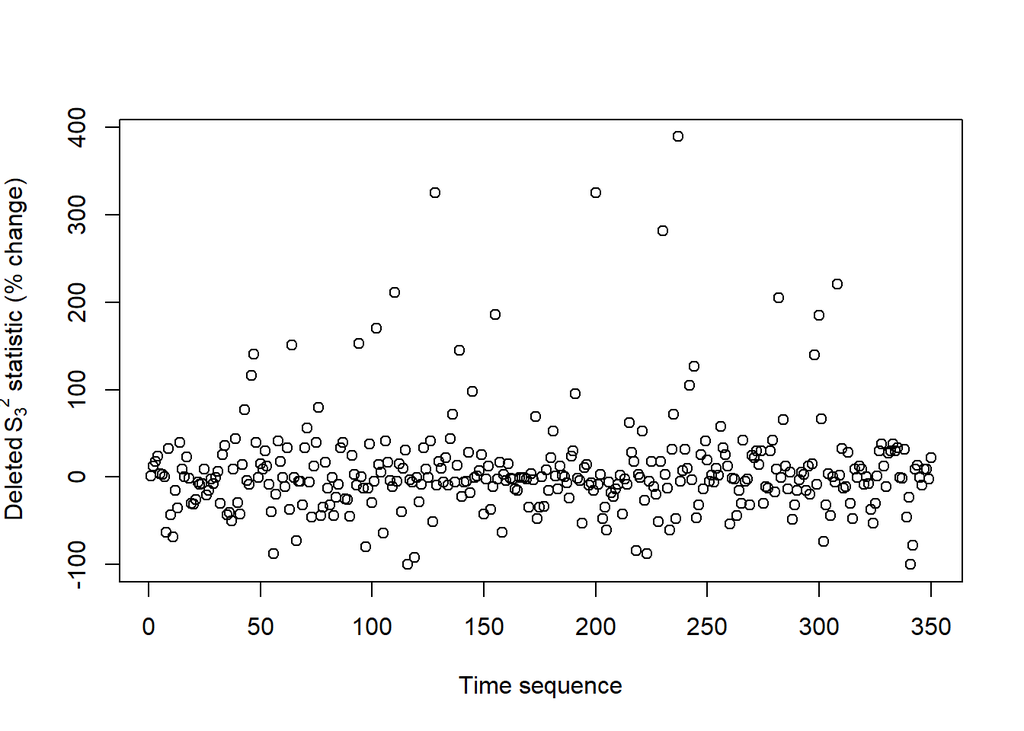

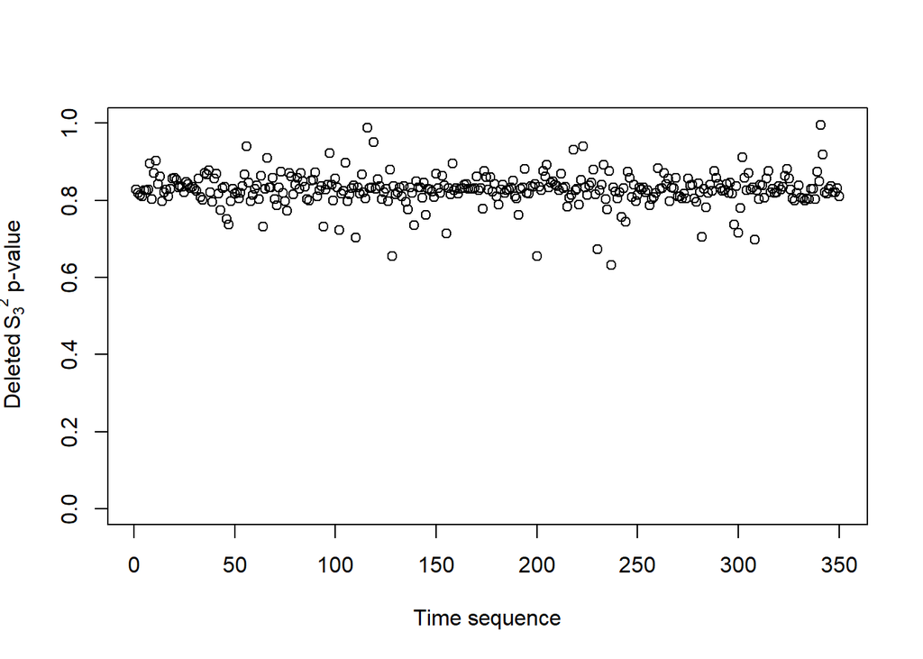

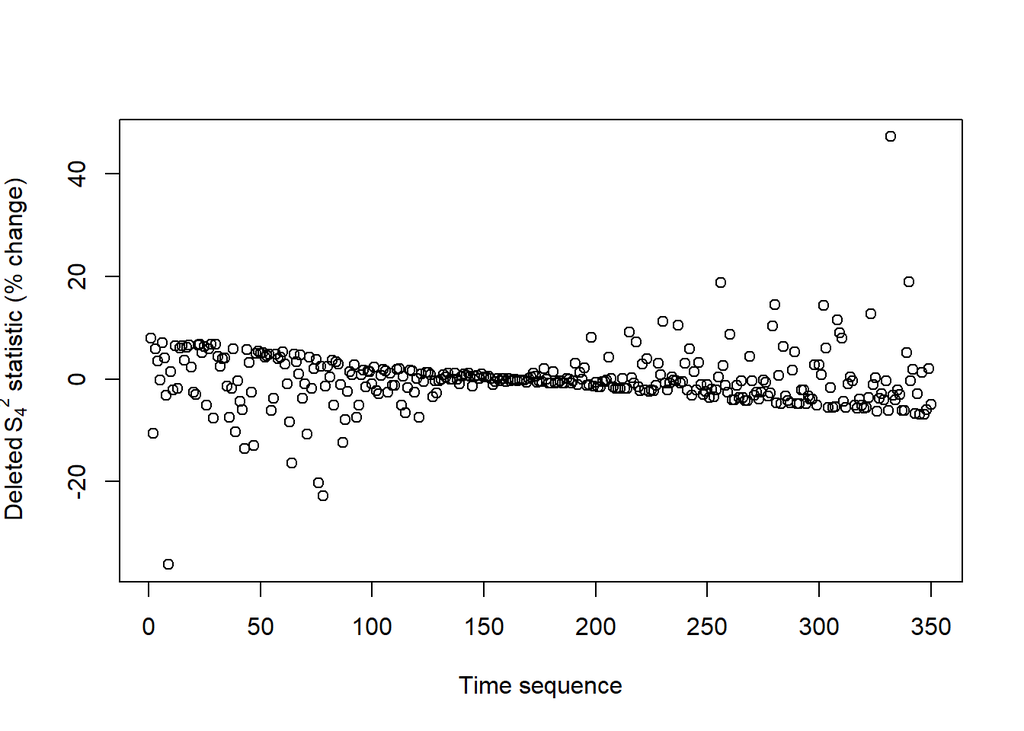

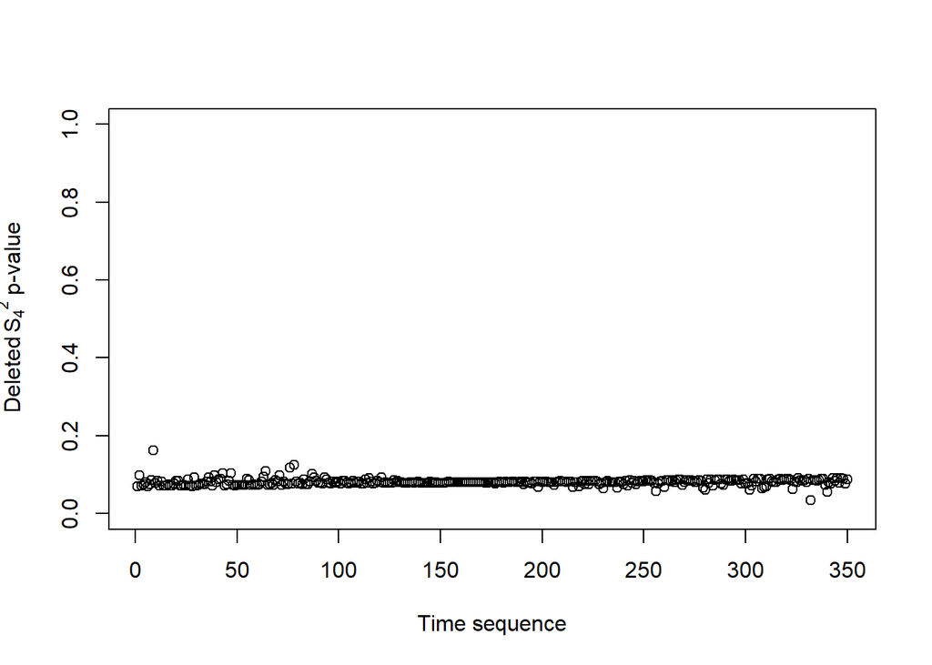

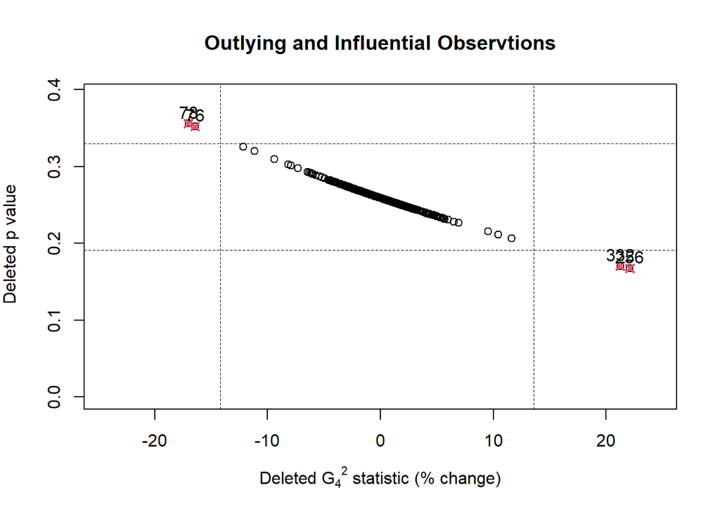

[13 more figures not shown]

```r
lm4 = lm(nflex_7~nflex_3+nflex_5+nflex_2, data=nflex_inv_reduct_msa)
ConditionRegression(lm4)
```

```r
summary(lm1)
```

```
##
## Call:
## lm(formula = nflex_2 ~ nflex_3 + nflex_5 + nflex_7, data = nflex_inv_reduct_msa)
##
## Residuals:
##      Min       1Q   Median       3Q      Max
## -2.43239 -0.63096 -0.05088  0.66561  1.98528
##
## Coefficients:
##             Estimate Std. Error t value             Pr(>|t|)
## (Intercept)  5.61897    0.20002  28.092 < 0.0000000000000002 ***
## nflex_3     -0.09947    0.03979  -2.500             0.012888 *
## nflex_5     -0.06184    0.03995  -1.548             0.122527
## nflex_7     -0.15984    0.04251  -3.760             0.000199 ***
## ---
## Signif. codes:  0 '***' 0.001 '**' 0.01 '*' 0.05 '.' 0.1 ' ' 1
##
## Residual standard error: 0.924 on 346 degrees of freedom
## Multiple R-squared:  0.09796,    Adjusted R-squared:  0.09013
## F-statistic: 12.52 on 3 and 346 DF,  p-value: 0.00000008579
```

```r
# summary(lm2)
# summary(lm3)
# summary(lm4)

#R² obtained with those regressions
c(.09796, .1277,.1005,.1609)
```

```
## [1] 0.09796 0.12770 0.10050 0.16090
```

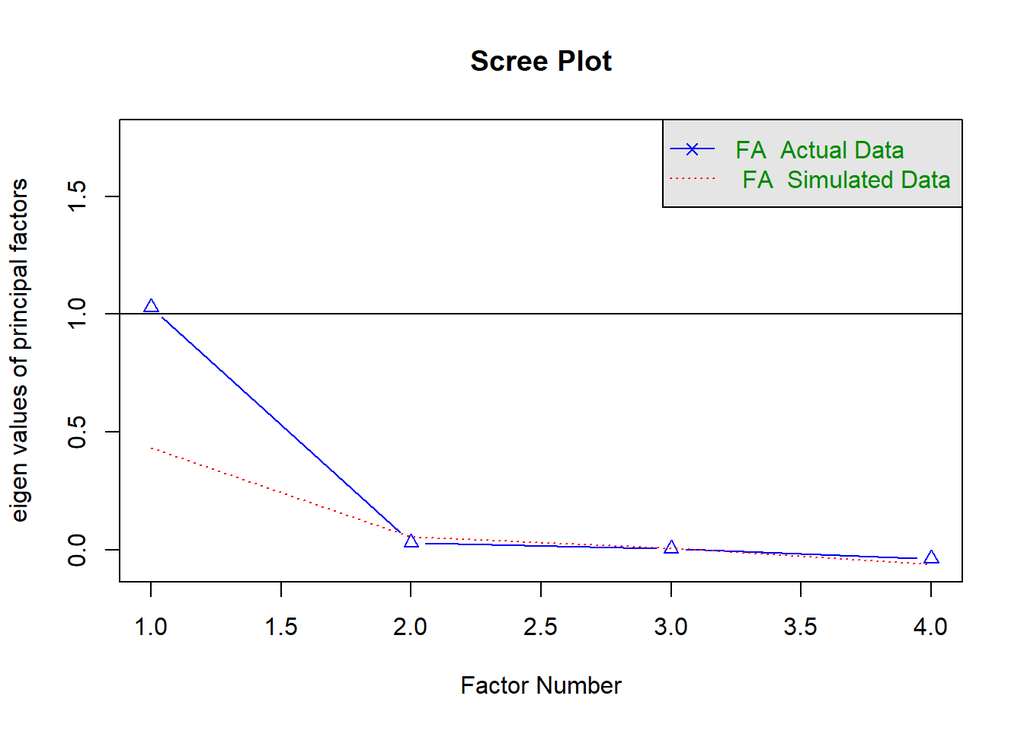

```
## Parallel analysis suggests that the number of factors =  1  and the number of components =  NA
```

```r
# Compute the number of factors
pa = fa.parallel(poly_nflex_inv_reduct_msa, fm="pa", fa="fa", main = "Scree Plot", se.bars = T, n.obs = n_row)
```

```r
vss(poly_nflex_inv_reduct_msa)
```

```
## n.obs was not specified and was arbitrarily set to 1000.  This only affects the chi square values.
```

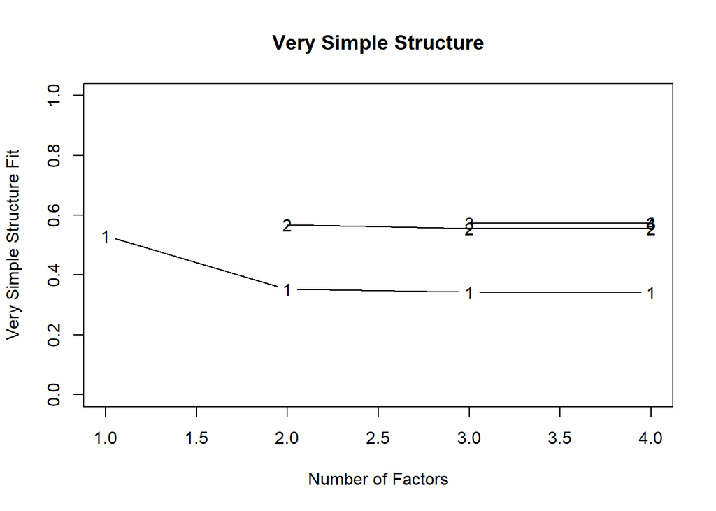

```
##
## Very Simple Structure
## Call: vss(x = poly_nflex_inv_reduct_msa)
## VSS complexity 1 achieves a maximimum of 0.53  with  1  factors
## VSS complexity 2 achieves a maximimum of 0.57  with  2  factors
##
## The Velicer MAP achieves a minimum of NA  with  1  factors
## BIC achieves a minimum of  NA  with  1  factors
## Sample Size adjusted BIC achieves a minimum of  NA  with  1  factors
##
## Statistics by number of factors
##   vss1 vss2  map dof           chisq prob sqresid  fit  RMSEA BIC SABIC complex
## 1 0.53 0.00 0.11   2 2.0188671660124 0.36     2.2 0.53 0.0029 -12  -5.4     1.0
## 2 0.35 0.57 0.39  -1 0.0000000000071   NA     2.1 0.57     NA  NA    NA     1.6
## 3 0.34 0.56 1.00  -3 0.0000000000000   NA     2.0 0.57     NA  NA    NA     1.8
## 4 0.34 0.56   NA  -4 0.0000000000000   NA     2.0 0.57     NA  NA    NA     1.8
##             eChisq        SRMR eCRMS eBIC
## 1 2.32087867700478 0.013907069 0.024  -11
## 2 0.00000000000776 0.000000025    NA   NA
## 3 0.00000000000011 0.000000003    NA   NA
## 4 0.00000000000011 0.000000003    NA   NA
```

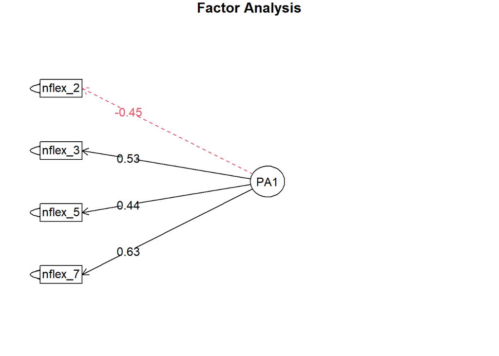

```r
# EFA with polychoric correlation and R² from multiple regression as original communalitites
fit_nflex = fa(nflex_inv_reduct_msa, cor="poly", nfactors = pa$nfact, fm="pa", rotate="none", residuals = T, correct=F, SMC=c(.09796, .1277,.1005,.1609))
fa.diagram(fit_nflex, sort = F, errors = T, labels = T, digits = 2, cut=.39)
```

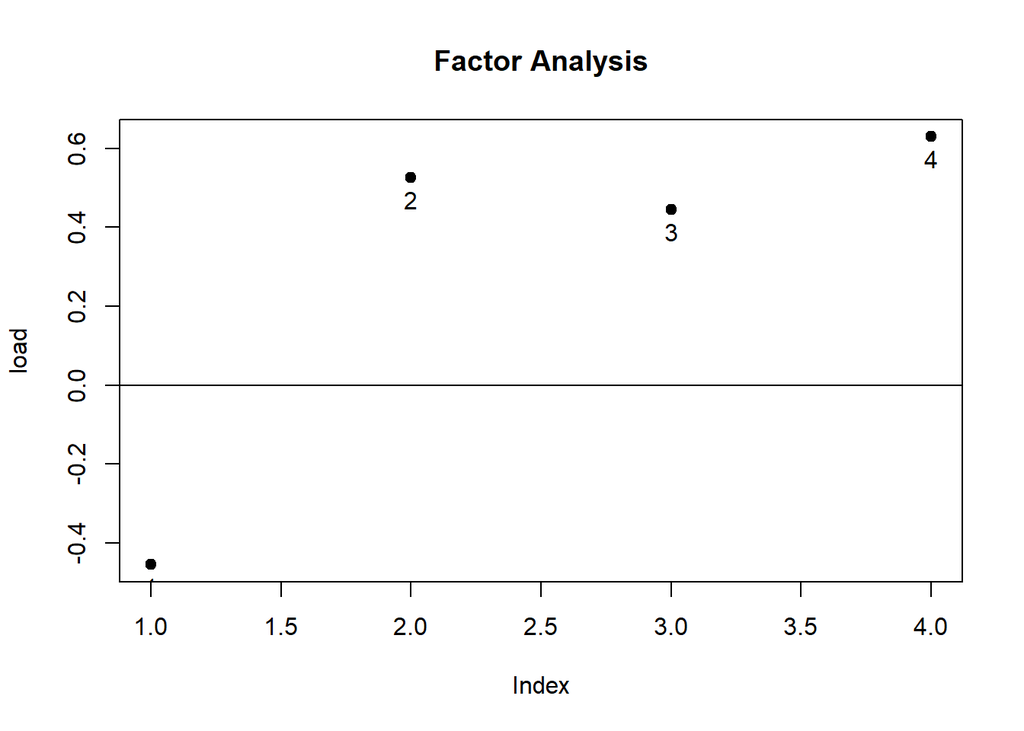

```r
fa.plot(fit_nflex) #plot the loadings of each factors
```

```r
fit_nflex
```

```
## Factor Analysis using method =  pa
## Call: fa(r = nflex_inv_reduct_msa, nfactors = pa$nfact, rotate = "none",
##     residuals = T, SMC = c(0.09796, 0.1277, 0.1005, 0.1609),
##     fm = "pa", cor = "poly", correct = F)
## Standardized loadings (pattern matrix) based upon correlation matrix
##           PA1   h2   u2 com
## nflex_2 -0.45 0.21 0.79   1
## nflex_3  0.53 0.28 0.72   1
## nflex_5  0.44 0.20 0.80   1
## nflex_7  0.63 0.40 0.60   1
##
##                 PA1
## SS loadings    1.08
## Proportion Var 0.27
##
## Mean item complexity =  1
## Test of the hypothesis that 1 factor is sufficient.
##
## The degrees of freedom for the null model are  6  and the objective function was  0.35 with Chi Square of  120.78
## The degrees of freedom for the model are 2  and the objective function was  0
##
## The root mean square of the residuals (RMSR) is  0.01
## The df corrected root mean square of the residuals is  0.02
##
## The harmonic number of observations is  350 with the empirical chi square  0.49  with prob <  0.78
## The total number of observations was  350  with Likelihood Chi Square =  0.44  with prob <  0.8
##
## Tucker Lewis Index of factoring reliability =  1.041
## RMSEA index =  0  and the 90 % confidence intervals are  0 0.066
## BIC =  -11.28
## Fit based upon off diagonal values = 1
## Measures of factor score adequacy
##                                                    PA1
## Correlation of (regression) scores with factors   0.78
## Multiple R square of scores with factors          0.61
## Minimum correlation of possible factor scores     0.21
```

```r
# Used to check if a general factor exist regrouping the other factor
# bassA = bassAckward(nflex_inv_reduct[,-c(5,6)], nfactors = c(1,1), fm = "pa", cor = "poly")
```

Fit index of the EFA shows how well the model is doing compare to a base model (all item in one factor). It also shows the fitting of items on the factors. We need to check for the **$\chi²$ test** (results close to 0 shows a perfect fit), the **root meant square residuals** (range between 0 and 1), the **standardized root mean residual** (SRMR), the **Tucker Lewis index** (TLI).  
The **$\chi²$ test** is used for hypothesis testing to evaluate the appropriateness of a structural equation model. It checks if the sample covariance matrix $S$ is equal to the model-implied covariance matrix $\Sigma (\theta)$ (Null hypothesis :$S-\Sigma (\hat{\theta})=0$). The **$\chi²$ test** is sensitive to number of observation. He will always be significant with more than 400 observations. (Schermelleh-Engel et al., 2003).  
Because exact fit never occurs, the null hypothesis of exact fit is replaced by the null hypothesis of “close-fit”. Thus, the **RMSEA** is a measure of approximate fit in the population and is therefore concerned with the discrepancy due to approximation. (Schermelleh-Engel et al., 2003). Steiger (1990) and Browne and Cudeck (1993) define a “close-fit” as a $RMSEA \leq .05$, an adequate fit as a $.05\leq RMSEA \leq.08$, a mediocre fit as $.08\leq RMSEA \leq.10$ and anythin else as not acceptable. For Hu and Bentler (1999), a cutoff of .06 is appropriate. RMSEA is relatively iundependent of sample size and favors parsimonious models (Browne and Cudeck, 1993 ; Kaplan, 2000).  
The **standardized root mean square residual** (SRMR) was developped to overcome the problems that comes along with the root mean residual, which is dependant on the siezs of the variance and covariances of the observed variables.A value of 0 indicates a perfect fit. But there is not real cutoff, as this value is still dependent of variance and covariances of the observed variables (even if less than for the RMR). Hu and Bentler (1995) suggested that $SRMR \leq .05$ indicate a good fit and $.05\leq SRMR \leq.10$ indicates an acceptable fit.  
The **Turker Lewis Index**, also known as **NonNormed Fit index** (Bentler and Bonnett, 1980) ranges from 0 to 1 but can sometime go beyond 1, as it is nonnormed. Less restrictive models (more complexe) are penalized while more persimonious models are rewarded by an increase in the fit index. This index is one of the less affected by sample size (Bentler, 1990 ; Hu et Bentler, 1998 ; Schermelleh-Engel et al., 2003)

*Références* :

Sharma, S., Mukherjee, S., Kumar, A., & Dillon, W. R. (2005). A simulation study to investigate the use of cutoff values for assessing model fit in covariance structure models. *Journal of Business Research, 58(7)*, 935‑943. https://doi.org/10.1016/j.jbusres.2003.10.007\

Bagozzi, R. R., & Yi, Y. (1988). On the evaluation of structural equation models. *Journal of the Academy of Marketing Science, 16(1)*, 74‑94. https://doi.org/0092-0703/88 / 1601-0074

Hu, L., & Bentler, P. M. (1999). Cutoff criteria for fit indexes in covariance structure analysis : Conventional criteria versus new alternatives. *Structural Equation Modeling: A Multidisciplinary Journal, 6(1)*, 1‑55. https://doi.org/10.1080/10705519909540118\

Schermelleh-Engel, K., Moosbrugger, H., & Müller, H. (2003). Evaluating the Fit of Structural Equation Models : Tests of Significance and Descriptive Goodness-of-Fit Measures. *Methods of Psychological Research, 8(2)*, 23‑74.

```r
omega(m=nflex_inv_reduct_msa, poly=T, nfactors = 1, fm = "pa", rotation="none", plot = T)
```

```
## Omega_h for 1 factor is not meaningful, just omega_t
```

```
## Omega
## Call: omegah(m = m, nfactors = nfactors, fm = fm, key = key, flip = flip,
##     digits = digits, title = title, sl = sl, labels = labels,
##     plot = plot, n.obs = n.obs, rotate = rotate, Phi = Phi, option = option,
##     covar = covar, rotation = "none")
## Alpha:                 0.57
## G.6:                   0.5
## Omega Hierarchical:    0.58
## Omega H asymptotic:    1
## Omega Total            0.57
##
## Schmid Leiman Factor loadings greater than  0.2
##             g  F1*   h2   u2 p2
## nflex_2- 0.42      0.18 0.82  1
## nflex_3  0.51      0.26 0.74  1
## nflex_5  0.44      0.20 0.80  1
## nflex_7  0.62      0.39 0.61  1
##
## With eigenvalues of:
##   g F1*
##   1   0
##
## general/max  18538007165697348   max/min =   1
## mean percent general =  1    with sd =  0 and cv of  0
## Explained Common Variance of the general factor =  1
##
## The degrees of freedom are 2  and the fit is  0
## The number of observations was  350  with Chi Square =  0.7  with prob <  0.7
## The root mean square of the residuals is  0.01
## The df corrected root mean square of the residuals is  0.02
## RMSEA index =  0  and the 10 % confidence intervals are  0 0.078
## BIC =  -11.01
##
## Compare this with the adequacy of just a general factor and no group factors
## The degrees of freedom for just the general factor are 2  and the fit is  0
## The number of observations was  350  with Chi Square =  0.7  with prob <  0.7
## The root mean square of the residuals is  0.01
## The df corrected root mean square of the residuals is  0.02
##
## RMSEA index =  0  and the 10 % confidence intervals are  0 0.078
## BIC =  -11.01
##
## Measures of factor score adequacy
##                                                  g F1*
## Correlation of scores with factors            0.77   0
## Multiple R square of scores with factors      0.59   0
## Minimum correlation of factor score estimates 0.19  -1
##
##  Total, General and Subset omega for each subset
##                                                  g  F1*
## Omega total for total scores and subscales    0.57 0.58
## Omega general for total scores and subscales  0.58 0.58
## Omega group for total scores and subscales    0.00 0.00
```

```r
psych::alpha(nflex_inv_reduct)
```

```
## Some items ( nflex_2 nflex_8 ) were negatively correlated with the total scale and
## probably should be reversed.
## To do this, run the function again with the 'check.keys=TRUE' option
```

```
##
## Reliability analysis
## Call: psych::alpha(x = nflex_inv_reduct)
##
##   raw_alpha std.alpha G6(smc) average_r  S/N   ase mean   sd median_r
##       0.28      0.22    0.31     0.046 0.29 0.057  3.8 0.57    0.033
##
##  lower alpha upper     95% confidence boundaries
## 0.17 0.28 0.39
##
##  Reliability if an item is dropped:
##         raw_alpha std.alpha G6(smc) average_r   S/N alpha se var.r   med.r
## nflex_2     0.420     0.402    0.41     0.118 0.672    0.048 0.033  0.1115
## nflex_3     0.171     0.120    0.23     0.027 0.136    0.068 0.046 -0.0062
## nflex_5     0.174     0.114    0.23     0.025 0.128    0.068 0.051 -0.0371
## nflex_7     0.098     0.061    0.12     0.013 0.065    0.075 0.023  0.0021
## nflex_8     0.352     0.282    0.35     0.073 0.392    0.051 0.056  0.1115
## nflex_9     0.157     0.091    0.18     0.020 0.101    0.069 0.046  0.0021
##
##  Item statistics
##           n raw.r std.r  r.cor r.drop mean   sd
## nflex_2 350 0.087  0.19 -0.240 -0.192  4.5 0.97
## nflex_3 350 0.564  0.52  0.366  0.212  3.5 1.32
## nflex_5 350 0.558  0.53  0.361  0.210  3.9 1.30
## nflex_7 350 0.614  0.57  0.567  0.303  3.4 1.24
## nflex_8 350 0.297  0.35  0.014 -0.034  4.3 1.13
## nflex_9 350 0.579  0.55  0.443  0.227  3.2 1.33
##
## Non missing response frequency for each item
##            1    2    3    4    5    6 miss
## nflex_2 0.00 0.01 0.13 0.39 0.29 0.18    0
## nflex_3 0.05 0.19 0.23 0.32 0.12 0.09    0
## nflex_5 0.04 0.13 0.19 0.33 0.20 0.11    0
## nflex_7 0.07 0.20 0.26 0.30 0.13 0.05    0
## nflex_8 0.01 0.06 0.16 0.35 0.28 0.14    0
## nflex_9 0.12 0.19 0.30 0.22 0.12 0.05    0
```

The Omega hierarchical is an estimation of the general factor saturation in a scale. The Omega asymptotic coefficient can be compare to a Guttman $\lambda^6$ (or the Cronbach $\alpha$).  
*Références*

Revelle and Zinbarg (2009)

Zinbarg, R. E., Revelle, W., Yovel, I., & Li, W. (2005). Cronbach’s α, Revelle’s β, and Mcdonald’s ωH : Their relations with each other and two alternative conceptualizations of reliability. *Psychometrika, 70(1)*, 123‑133. https://doi.org/10.1007/s11336-003-0974-7

Trizano-Hermosilla, I., & Alvarado, J. M. (2016). Best Alternatives to Cronbach’s Alpha Reliability in Realistic Conditions : Congeneric and Asymmetrical Measurements. *Frontiers in Psychology, 7(769)*. https://doi.org/10.3389/fpsyg.2016.00769

# V. **Confirmatory Factor Analysis**

## 1. **Creation of cfa models**

Create models used for the cfa. It implies the 3 scales already validated (cfs, attention switching sub-set, cognitive rigidity sub-set).

```r
model_cfs = "flexibilite =~ cfs_1+cfs_2+cfs_3+cfs_4+cfs_5+cfs_6+cfs_7+cfs_8+cfs_9+cfs_10+cfs_11+cfs_12"

model_aq = "attention =~ att_switch_1+att_switch_2+att_switch_3+att_switch_4+att_switch_5+att_switch_6+att_switch_7+att_switch_8+att_switch_9+att_switch_10"

model_rtc = "rigidite =~ cognitive_rigidity_1+cognitive_rigidity_2+cognitive_rigidity_3+cognitive_rigidity_4"
```

## 2. **CFA for the cognitive flexibility scale**

```r
cfa_cfs = cfa(model_cfs, data=data_cleaned_scale[,31:42], estimator="DWLS", ordered = c("cfs_1","cfs_2","cfs_3","cfs_4","cfs_5","cfs_6","cfs_7","cfs_8","cfs_9","cfs_10","cfs_11","cfs_12"))
summary(cfa_cfs, fit.measures=T)
```

```
## lavaan 0.6-5 ended normally after 16 iterations
##
##   Estimator                                       DWLS
##   Optimization method                           NLMINB
##   Number of free parameters                         71
##
##   Number of observations                           350
##
## Model Test User Model:
##
##   Test statistic                               307.456
##   Degrees of freedom                                54
##   P-value (Chi-square)                           0.000
##
## Model Test Baseline Model:
##
##   Test statistic                              2398.385
##   Degrees of freedom                                66
##   P-value                                        0.000
##
## User Model versus Baseline Model:
##
##   Comparative Fit Index (CFI)                    0.891
##   Tucker-Lewis Index (TLI)                       0.867
##
## Root Mean Square Error of Approximation:
##
##   RMSEA                                          0.116
##   90 Percent confidence interval - lower         0.104
##   90 Percent confidence interval - upper         0.129
##   P-value RMSEA <= 0.05                          0.000
##
## Standardized Root Mean Square Residual:
##
##   SRMR                                           0.093
##
## Parameter Estimates:
##
##   Information                                 Expected
##   Information saturated (h1) model        Unstructured
```

[output cut: 111 more lines]

```
##
## Scales y*:
##                    Estimate  Std.Err  z-value  P(>|z|)
##     cfs_1             1.000
##     cfs_2             1.000
##     cfs_3             1.000
##     cfs_4             1.000
##     cfs_5             1.000
##     cfs_6             1.000
##     cfs_7             1.000
##     cfs_8             1.000
##     cfs_9             1.000
##     cfs_10            1.000
##     cfs_11            1.000
##     cfs_12            1.000
```

```r
psych::alpha(data_cleaned_scale[,31:42])
```

```
##
## Reliability analysis
## Call: psych::alpha(x = data_cleaned_scale[, 31:42])
##
##   raw_alpha std.alpha G6(smc) average_r S/N   ase mean   sd median_r
##       0.76      0.77    0.79      0.22 3.3 0.019  4.3 0.59     0.21
##
##  lower alpha upper     95% confidence boundaries
## 0.73 0.76 0.8
##
##  Reliability if an item is dropped:
##        raw_alpha std.alpha G6(smc) average_r S/N alpha se  var.r med.r
## cfs_1       0.74      0.74    0.76      0.21 2.8    0.021 0.0120  0.20
## cfs_2       0.76      0.76    0.78      0.22 3.2    0.019 0.0108  0.21
## cfs_3       0.75      0.76    0.77      0.22 3.1    0.020 0.0113  0.21
## cfs_4       0.74      0.75    0.77      0.21 3.0    0.020 0.0121  0.21
## cfs_5       0.75      0.76    0.78      0.22 3.2    0.020 0.0123  0.21
## cfs_6       0.74      0.74    0.76      0.21 2.9    0.020 0.0114  0.21
## cfs_7       0.74      0.75    0.76      0.21 3.0    0.020 0.0116  0.20
## cfs_8       0.76      0.76    0.77      0.22 3.2    0.019 0.0097  0.22
## cfs_9       0.76      0.76    0.78      0.23 3.2    0.019 0.0110  0.22
## cfs_10      0.74      0.75    0.77      0.21 3.0    0.020 0.0126  0.20
## cfs_11      0.75      0.76    0.78      0.22 3.1    0.019 0.0120  0.22
## cfs_12      0.73      0.74    0.76      0.20 2.8    0.022 0.0122  0.20
##
##  Item statistics
##          n raw.r std.r r.cor r.drop mean   sd
## cfs_1  350  0.61  0.63  0.59   0.51  4.7 1.05
## cfs_2  350  0.49  0.46  0.38   0.34  4.2 1.25
## cfs_3  350  0.54  0.50  0.43   0.38  4.2 1.41
## cfs_4  350  0.55  0.56  0.51   0.43  4.1 1.00
## cfs_5  350  0.48  0.47  0.38   0.35  4.4 1.10
## cfs_6  350  0.58  0.59  0.56   0.47  4.8 0.99
## cfs_7  350  0.54  0.56  0.52   0.43  4.3 0.93
## cfs_8  350  0.46  0.47  0.42   0.33  4.2 1.11
## cfs_9  350  0.42  0.44  0.36   0.28  4.2 1.05
## cfs_10 350  0.56  0.54  0.48   0.43  4.3 1.21
## cfs_11 350  0.46  0.49  0.41   0.34  5.0 0.98
## cfs_12 350  0.66  0.65  0.61   0.55  3.8 1.24
##
## Non missing response frequency for each item
##           1    2    3    4    5    6 miss
## cfs_1  0.00 0.02 0.11 0.31 0.30 0.26    0
## cfs_2  0.03 0.06 0.21 0.31 0.24 0.16    0
## cfs_3  0.06 0.06 0.18 0.24 0.26 0.20    0
## cfs_4  0.01 0.06 0.15 0.48 0.22 0.08    0
## cfs_5  0.01 0.03 0.16 0.29 0.34 0.17    0
## cfs_6  0.00 0.02 0.06 0.35 0.29 0.28    0
## cfs_7  0.00 0.03 0.11 0.46 0.28 0.11    0
## cfs_8  0.02 0.03 0.19 0.39 0.23 0.14    0
## cfs_9  0.01 0.04 0.18 0.45 0.19 0.13    0
## cfs_10 0.03 0.05 0.15 0.31 0.29 0.17    0
## cfs_11 0.00 0.01 0.04 0.27 0.29 0.38    0
## cfs_12 0.05 0.08 0.25 0.35 0.18 0.10    0
```

```r
poly = polychoric(data_cleaned_scale[,31:42])
poly = poly$rho
omega(poly, nfactors = 1, fm = "pa", sl=T, rotation="none")
```

```
## Omega_h for 1 factor is not meaningful, just omega_t
```

```
## Omega
## Call: omegah(m = m, nfactors = nfactors, fm = fm, key = key, flip = flip,
##     digits = digits, title = title, sl = sl, labels = labels,
##     plot = plot, n.obs = n.obs, rotate = rotate, Phi = Phi, option = option,
##     covar = covar, rotation = "none")
## Alpha:                 0.79
## G.6:                   0.81
## Omega Hierarchical:    0.8
## Omega H asymptotic:    1
## Omega Total            0.8
##
## Schmid Leiman Factor loadings greater than  0.2
##           g  F1*   h2   u2 p2
## cfs_1  0.62      0.38 0.62  1
## cfs_2  0.41      0.17 0.83  1
## cfs_3  0.45      0.20 0.80  1
## cfs_4  0.54      0.29 0.71  1
## cfs_5  0.41      0.17 0.83  1
## cfs_6  0.61      0.37 0.63  1
## cfs_7  0.49      0.24 0.76  1
## cfs_8  0.41      0.17 0.83  1
## cfs_9  0.39      0.15 0.85  1
## cfs_10 0.51      0.26 0.74  1
## cfs_11 0.49      0.24 0.76  1
## cfs_12 0.61      0.37 0.63  1
##
## With eigenvalues of:
##   g F1*
##   3   0
##
## general/max  21638710718119032   max/min =   1
## mean percent general =  1    with sd =  0 and cv of  0
## Explained Common Variance of the general factor =  1
##
## The degrees of freedom are 54  and the fit is  0.8
##
## The root mean square of the residuals is  0.09
## The df corrected root mean square of the residuals is  0.1
##
## Compare this with the adequacy of just a general factor and no group factors
## The degrees of freedom for just the general factor are 54  and the fit is  0.8
##
## The root mean square of the residuals is  0.09
## The df corrected root mean square of the residuals is  0.1
##
## Measures of factor score adequacy
##                                                  g F1*
## Correlation of scores with factors            0.90   0
## Multiple R square of scores with factors      0.81   0
## Minimum correlation of factor score estimates 0.62  -1
##
##  Total, General and Subset omega for each subset
##                                                 g F1*
## Omega total for total scores and subscales    0.8 0.8
## Omega general for total scores and subscales  0.8 0.8
## Omega group for total scores and subscales    0.0 0.0
```

## 3. **CFA for the attention switching sub-scale**

```r
cfa_aq = cfa(model_aq, data=data_cleaned_scale[,11:20], estimator="DWLS", ordered = c("att_switch_1","att_switch_2","att_switch_3","att_switch_4","att_switch_5","att_switch_6","att_switch_7","att_switch_8","att_switch_9","att_switch_10"))
summary(cfa_aq, fit.measures=T)
```

```
## lavaan 0.6-5 ended normally after 21 iterations
##
##   Estimator                                       DWLS
##   Optimization method                           NLMINB
##   Number of free parameters                         40
##
##   Number of observations                           350
##
## Model Test User Model:
##
##   Test statistic                               251.753
##   Degrees of freedom                                35
##   P-value (Chi-square)                           0.000
##
## Model Test Baseline Model:
##
##   Test statistic                               722.203
##   Degrees of freedom                                45
##   P-value                                        0.000
##
## User Model versus Baseline Model:
##
##   Comparative Fit Index (CFI)                    0.680
##   Tucker-Lewis Index (TLI)                       0.588
##
## Root Mean Square Error of Approximation:
##
##   RMSEA                                          0.133
##   90 Percent confidence interval - lower         0.118
##   90 Percent confidence interval - upper         0.149
##   P-value RMSEA <= 0.05                          0.000
##
## Standardized Root Mean Square Residual:
##
##   SRMR                                           0.118
##
## Parameter Estimates:
##
##   Information                                 Expected
##   Information saturated (h1) model        Unstructured
```

[output cut: 74 more lines]

```
##    .att_switch_10     0.717
##     attention         0.211    0.042    4.977    0.000
##
## Scales y*:
##                    Estimate  Std.Err  z-value  P(>|z|)
##     att_switch_1      1.000
##     att_switch_2      1.000
##     att_switch_3      1.000
##     att_switch_4      1.000
##     att_switch_5      1.000
##     att_switch_6      1.000
##     att_switch_7      1.000
##     att_switch_8      1.000
##     att_switch_9      1.000
##     att_switch_10     1.000
```

```r
psych::alpha(data_cleaned_scale[,11:20])
```

```
##
## Reliability analysis
## Call: psych::alpha(x = data_cleaned_scale[, 11:20])
##
##   raw_alpha std.alpha G6(smc) average_r S/N   ase mean  sd median_r
##        0.6       0.6    0.63      0.13 1.5 0.032  2.6 0.4     0.13
##
##  lower alpha upper     95% confidence boundaries
## 0.54 0.6 0.66
##
##  Reliability if an item is dropped:
##               raw_alpha std.alpha G6(smc) average_r S/N alpha se var.r med.r
## att_switch_1       0.57      0.57    0.60      0.13 1.3    0.034 0.015  0.13
## att_switch_2       0.59      0.59    0.61      0.14 1.4    0.033 0.017  0.14
## att_switch_3       0.59      0.59    0.61      0.14 1.5    0.032 0.013  0.15
## att_switch_4       0.60      0.60    0.62      0.14 1.5    0.032 0.015  0.13
## att_switch_5       0.53      0.54    0.57      0.12 1.2    0.038 0.016  0.11
## att_switch_6       0.57      0.57    0.58      0.13 1.3    0.034 0.013  0.13
## att_switch_7       0.57      0.57    0.60      0.13 1.4    0.034 0.016  0.12
## att_switch_8       0.57      0.57    0.59      0.13 1.3    0.035 0.016  0.11
## att_switch_9       0.59      0.59    0.61      0.14 1.4    0.033 0.014  0.13
## att_switch_10      0.55      0.56    0.58      0.12 1.3    0.036 0.015  0.12
##
##  Item statistics
##                 n raw.r std.r r.cor r.drop mean   sd
## att_switch_1  350  0.45  0.48  0.38   0.29  2.4 0.71
## att_switch_2  350  0.41  0.41  0.28   0.22  2.5 0.85
## att_switch_3  350  0.40  0.41  0.30   0.19  2.9 0.86
## att_switch_4  350  0.39  0.36  0.22   0.17  2.3 0.93
## att_switch_5  350  0.61  0.59  0.54   0.43  2.8 0.92
## att_switch_6  350  0.48  0.50  0.44   0.30  2.9 0.81
## att_switch_7  350  0.46  0.47  0.37   0.28  3.1 0.78
## att_switch_8  350  0.48  0.49  0.40   0.30  3.0 0.79
## att_switch_9  350  0.44  0.43  0.31   0.22  2.2 0.91
## att_switch_10 350  0.55  0.53  0.46   0.35  2.4 0.93
##
## Non missing response frequency for each item
##                  1    2    3    4 miss
## att_switch_1  0.07 0.57 0.29 0.07    0
## att_switch_2  0.12 0.39 0.38 0.11    0
## att_switch_3  0.08 0.19 0.48 0.25    0
## att_switch_4  0.22 0.35 0.33 0.10    0
## att_switch_5  0.11 0.24 0.42 0.23    0
## att_switch_6  0.07 0.19 0.54 0.21    0
## att_switch_7  0.03 0.18 0.47 0.33    0
## att_switch_8  0.03 0.19 0.47 0.30    0
## att_switch_9  0.25 0.42 0.23 0.09    0
## att_switch_10 0.17 0.38 0.31 0.14    0
```

```r
poly = polychoric(data_cleaned_scale[,11:20])
poly = poly$rho
omega(poly, nfactors = 1, fm = "pa", sl=T, rotation="none")
```

```
## Omega_h for 1 factor is not meaningful, just omega_t
```

```
## Omega
## Call: omegah(m = m, nfactors = nfactors, fm = fm, key = key, flip = flip,
##     digits = digits, title = title, sl = sl, labels = labels,
##     plot = plot, n.obs = n.obs, rotate = rotate, Phi = Phi, option = option,
##     covar = covar, rotation = "none")
## Alpha:                 0.64
## G.6:                   0.68
## Omega Hierarchical:    0.64
## Omega H asymptotic:    0.99
## Omega Total            0.65
##
## Schmid Leiman Factor loadings greater than  0.2
##                  g  F1*   h2   u2 p2
## att_switch_1  0.46      0.21 0.79  1
## att_switch_2  0.24      0.06 0.94  1
## att_switch_3  0.25      0.06 0.94  1
## att_switch_4  0.22      0.05 0.95  1
## att_switch_5  0.65      0.43 0.57  1
## att_switch_6  0.36      0.13 0.87  1
## att_switch_7  0.41      0.17 0.83  1
## att_switch_8  0.36      0.13 0.87  1
## att_switch_9  0.37      0.14 0.86  1
## att_switch_10 0.55      0.30 0.70  1
##
## With eigenvalues of:
##   g F1*
## 1.7 0.0
##
## general/max  60305350138788240   max/min =   1
## mean percent general =  1    with sd =  0 and cv of  0
## Explained Common Variance of the general factor =  1
##
## The degrees of freedom are 35  and the fit is  0.85
##
## The root mean square of the residuals is  0.13
## The df corrected root mean square of the residuals is  0.15
##
## Compare this with the adequacy of just a general factor and no group factors
## The degrees of freedom for just the general factor are 35  and the fit is  0.85
##
## The root mean square of the residuals is  0.13
## The df corrected root mean square of the residuals is  0.15
##
## Measures of factor score adequacy
##                                                  g F1*
## Correlation of scores with factors            0.83   0
## Multiple R square of scores with factors      0.69   0
## Minimum correlation of factor score estimates 0.39  -1
##
##  Total, General and Subset omega for each subset
##                                                  g  F1*
## Omega total for total scores and subscales    0.65 0.64
## Omega general for total scores and subscales  0.64 0.64
## Omega group for total scores and subscales    0.00 0.00
```

## 4. **CFA for the cognitive rigidity sub-scale**

```r
cfa_rtc = cfa(model_rtc, data=data_cleaned_scale[,7:10], estimator="DWLS", ordered=c("cognitive_rigidity_1","cognitive_rigidity_2","cognitive_rigidity_3","cognitive_rigidity_4") )
summary(cfa_rtc, fit.measures=T)
```

```
## lavaan 0.6-5 ended normally after 13 iterations
##
##   Estimator                                       DWLS
##   Optimization method                           NLMINB
##   Number of free parameters                         24
##
##   Number of observations                           350
##
## Model Test User Model:
##
##   Test statistic                                17.818
##   Degrees of freedom                                 2
##   P-value (Chi-square)                           0.000
##
## Model Test Baseline Model:
##
##   Test statistic                               721.928
##   Degrees of freedom                                 6
##   P-value                                        0.000
##
## User Model versus Baseline Model:
##
##   Comparative Fit Index (CFI)                    0.978
##   Tucker-Lewis Index (TLI)                       0.934
##
## Root Mean Square Error of Approximation:
##
##   RMSEA                                          0.151
##   90 Percent confidence interval - lower         0.092
##   90 Percent confidence interval - upper         0.218
##   P-value RMSEA <= 0.05                          0.004
##
## Standardized Root Mean Square Residual:
##
##   SRMR                                           0.054
##
## Parameter Estimates:
##
##   Information                                 Expected
##   Information saturated (h1) model        Unstructured
```

[output cut: 40 more lines]

```
##
## Variances:
##                    Estimate  Std.Err  z-value  P(>|z|)
##    .cogntv_rgdty_1    0.586
##    .cogntv_rgdty_2    0.684
##    .cogntv_rgdty_3    0.455
##    .cogntv_rgdty_4    0.568
##     rigidite          0.414    0.050    8.249    0.000
##
## Scales y*:
##                    Estimate  Std.Err  z-value  P(>|z|)
##     cogntv_rgdty_1    1.000
##     cogntv_rgdty_2    1.000
##     cogntv_rgdty_3    1.000
##     cogntv_rgdty_4    1.000
```

```r
psych::alpha(data_cleaned_scale[,7:10])
```

```
##
## Reliability analysis
## Call: psych::alpha(x = data_cleaned_scale[, 7:10])
##
##   raw_alpha std.alpha G6(smc) average_r S/N   ase mean   sd median_r
##       0.71      0.72    0.67      0.39 2.5 0.025  3.5 0.83     0.41
##
##  lower alpha upper     95% confidence boundaries
## 0.66 0.71 0.76
##
##  Reliability if an item is dropped:
##                      raw_alpha std.alpha G6(smc) average_r S/N alpha se  var.r
## cognitive_rigidity_1      0.65      0.66    0.57      0.39 1.9    0.032 0.0051
## cognitive_rigidity_2      0.69      0.70    0.61      0.43 2.3    0.028 0.0017
## cognitive_rigidity_3      0.60      0.61    0.53      0.34 1.6    0.037 0.0131
## cognitive_rigidity_4      0.65      0.65    0.57      0.38 1.8    0.033 0.0141
##                      med.r
## cognitive_rigidity_1  0.39
## cognitive_rigidity_2  0.44
## cognitive_rigidity_3  0.32
## cognitive_rigidity_4  0.44
##
##  Item statistics
##                        n raw.r std.r r.cor r.drop mean  sd
## cognitive_rigidity_1 350  0.73  0.73  0.60   0.49  3.6 1.2
## cognitive_rigidity_2 350  0.70  0.69  0.52   0.43  3.5 1.2
## cognitive_rigidity_3 350  0.78  0.78  0.68   0.58  3.3 1.1
## cognitive_rigidity_4 350  0.72  0.74  0.60   0.51  3.7 1.0
##
## Non missing response frequency for each item
##                         1    2    3    4    5    6 miss
## cognitive_rigidity_1 0.06 0.10 0.27 0.35 0.18 0.03    0
## cognitive_rigidity_2 0.05 0.15 0.31 0.29 0.15 0.05    0
## cognitive_rigidity_3 0.05 0.18 0.33 0.31 0.10 0.02    0
## cognitive_rigidity_4 0.02 0.11 0.21 0.47 0.15 0.03    0
```

```r
poly = polychoric(data_cleaned_scale[,7:10])
poly = poly$rho
omega(poly, nfactors = 1, fm = "pa", sl=T, rotation="none")
```

```
## Omega_h for 1 factor is not meaningful, just omega_t
```

```
## Omega
## Call: omegah(m = m, nfactors = nfactors, fm = fm, key = key, flip = flip,
##     digits = digits, title = title, sl = sl, labels = labels,
##     plot = plot, n.obs = n.obs, rotate = rotate, Phi = Phi, option = option,
##     covar = covar, rotation = "none")
## Alpha:                 0.71
## G.6:                   0.66
## Omega Hierarchical:    0.71
## Omega H asymptotic:    1
## Omega Total            0.71
##
## Schmid Leiman Factor loadings greater than  0.2
##                         g  F1*   h2   u2 p2
## cognitive_rigidity_1 0.61      0.37 0.63  1
## cognitive_rigidity_2 0.54      0.29 0.71  1
## cognitive_rigidity_3 0.70      0.49 0.51  1
## cognitive_rigidity_4 0.62      0.38 0.62  1
##
## With eigenvalues of:
##   g F1*
## 1.5 0.0
##
## general/max  27768076668289628   max/min =   1
## mean percent general =  1    with sd =  0 and cv of  0
## Explained Common Variance of the general factor =  1
##
## The degrees of freedom are 2  and the fit is  0.06
##
## The root mean square of the residuals is  0.06
## The df corrected root mean square of the residuals is  0.1
##
## Compare this with the adequacy of just a general factor and no group factors
## The degrees of freedom for just the general factor are 2  and the fit is  0.06
##
## The root mean square of the residuals is  0.06
## The df corrected root mean square of the residuals is  0.1
##
## Measures of factor score adequacy
##                                                  g F1*
## Correlation of scores with factors            0.85   0
## Multiple R square of scores with factors      0.72   0
## Minimum correlation of factor score estimates 0.45  -1
##
##  Total, General and Subset omega for each subset
##                                                  g  F1*
## Omega total for total scores and subscales    0.71 0.71
## Omega general for total scores and subscales  0.71 0.71
## Omega group for total scores and subscales    0.00 0.00
```

# VI. **Scale validation**

## 1. **Convergence**

### a. *Sum computation*

```r
#Sum for the all scales
data_cleaned_wcst$sum_nflex = apply(data_cleaned_wcst[,c("nflex_2","nflex_3","nflex_5","nflex_7")], 1, sum)
data_cleaned_wcst$sum_as = apply(data_cleaned_wcst[,c(11:20)], 1, sum)
data_cleaned_wcst$sum_cr = apply(data_cleaned_wcst[,c(7:10)], 1, sum)
data_cleaned_wcst$sum_cfs = apply(data_cleaned_wcst[,c(31:42)], 1, sum)
```

### b. *convergence validity*

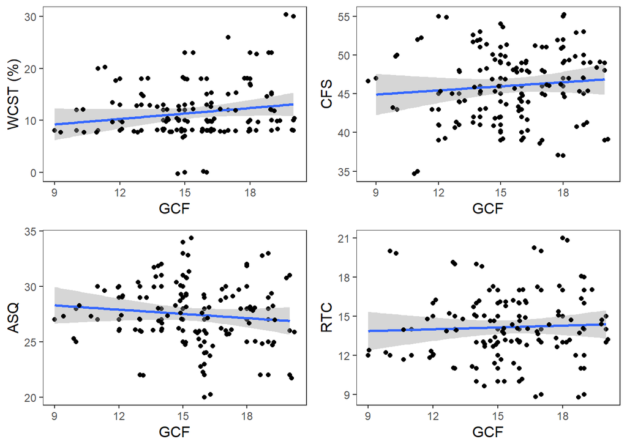

```r
a = ggplot(data_cleaned_wcst, aes(x=sum_nflex, y=sum_cr))+
  geom_point()+
  geom_smooth(method="lm", se=TRUE) +
  geom_jitter() +
  theme_apa() +
  xlab("GCF") +
  ylab("RTC")

b = ggplot(data_cleaned_wcst, aes(x=sum_nflex, y=sum_as))+
  geom_point()+
  geom_smooth(method="lm", se=TRUE)+geom_jitter() +
  theme_apa() +
  xlab("GCF") +
  ylab("ASQ")

c = ggplot(data_cleaned_wcst, aes(x=sum_nflex, y=sum_cfs))+
  geom_point()+
  geom_smooth(method="lm", se=TRUE)+geom_jitter() +
  theme_apa() +
  xlab("GCF") +
  ylab("CFS")

d = ggplot(data_cleaned_wcst, aes(x=sum_nflex, y=pourcentage))+
  geom_point()+
  geom_smooth(method="lm", se=TRUE)+geom_jitter() +
  theme_apa() +
  xlab("GCF") +
  ylab("WCST (%)")

figure = ggarrange(d,c,b,a, ncol=2, nrow=2)
figure
```

```r
Hmisc::rcorr(as.matrix(data_cleaned_wcst[,c(46, 49:52)]), type="pearson")
```

```
##             pourcentage sum_nflex sum_as sum_cr sum_cfs
## pourcentage        1.00      0.17   0.09   0.14   -0.05
## sum_nflex          0.17      1.00  -0.11   0.05    0.10
## sum_as             0.09     -0.11   1.00   0.15    0.25
## sum_cr             0.14      0.05   0.15   1.00    0.02
## sum_cfs           -0.05      0.10   0.25   0.02    1.00
##
## n= 87
##
##
## P
##             pourcentage sum_nflex sum_as sum_cr sum_cfs
## pourcentage             0.1135    0.3885 0.2122 0.6735
## sum_nflex   0.1135                0.2903 0.6619 0.3637
## sum_as      0.3885      0.2903           0.1547 0.0217
## sum_cr      0.2122      0.6619    0.1547        0.8284
## sum_cfs     0.6735      0.3637    0.0217 0.8284
```